# SBLI Sentiment Analysis

Ankita Guha

April 5, 2019

```r
#Installing Libraries
library(plyr)
library(tidytext)
library(janeaustenr)
library(stringr)
library(rJava) # qdap needs Java platform. Checkout how to install rJava.
library(qdap)
library(dplyr)
library(tm)
```

```r
library(wordcloud)
library(plotrix)
library(dendextend)
library(ggplot2)
library(ggthemes)
library(RWeka)
library(reshape2)
library(quanteda)
```

## Reading Data & Initial pre-processing

```r
# Reading Data File
SBLI <- read.csv(file="sblidata.csv", header=TRUE, sep=",", stringsAsFactors = FALSE, encoding = 'UTF=8') #"encoding = 'UTF-8'" enables the removal of all the strange characters embedded within the text. Try to read the file without the encoding and see all the appostrophe are replaced by a strange symbol

# Removing Columns "Gaschoice" & "EleChoice"
SBLI <- subset(SBLI, select = -c(GasChoice, EleChoice))

#Changing Column "What.does.DTE.do.well.to.earn.your.satisfaction.": First Column
colnames(SBLI)[which(names(SBLI) == "What_does_DTE_do_well_to_earn_your_sat")] <- "EarnSatisfaction"

#Changing Column "What.does.DTE.need.to.improve.other.than.price.to.earn.your.satisfaction.": Second Column
colnames(SBLI)[which(names(SBLI) == "What_does_DTE_need_to_improve_other_than_price_to_earn_your_sat")] <- "ImproveSatisfaction"


library("lubridate")
SBLI$SurveyEndDate <- as.Date(dmy(SBLI$SurveyEndDate))
```

```r
#library("VIM")
#aggr(SBLI)
```

### Step 1:

## Text Extraction

```r
## Make a vector source and a corpus for both the Columns containing the Customer Satisfaction Data
#Column 1: EarnSatisfaction
corpus_review1 <- Corpus(VectorSource(SBLI$EarnSatisfaction))

#Column 2: ImproveSatisfaction
corpus_review2 <- Corpus(VectorSource(SBLI$ImproveSatisfaction))
```

### Step 2:

## i) Convert to Lower Case

```r
#Converting 1st Column to Lowercase: Converting corpus_review1
corpus_review1<-tm_map(corpus_review1, tolower)
#Converting 2nd Column to Lowercase: Converting corpus_review2
corpus_review2<-tm_map(corpus_review2, tolower)
```

## ii) Remove Punctuation

```r
#Removing Punctuation from 1st & 2nd Column
corpus_review1<-tm_map(corpus_review1, removePunctuation)
corpus_review2<-tm_map(corpus_review2, removePunctuation)
```

## iii) Remove Stopwords & Remove Numbers

```r
#Remove stopwords from 1st & 2nd Column
corpus_review1<-tm_map(corpus_review1, removeWords, stopwords("english"))
corpus_review2<-tm_map(corpus_review2, removeWords, stopwords("english"))
#Remove Numbers from 1st & 2nd Column
corpus_review1<-tm_map(corpus_review1, removeNumbers)
corpus_review2<-tm_map(corpus_review2, removeNumbers)
```

## iv) Remove Context Specific Words

```r
#Remove context specific words from 1st & 2nd Column
corpus_review1<-tm_map(corpus_review1, removeWords,c("dte", "keep", "company", "energy", "provide", "gas", "electri*", "bill*", "need", "work" ))
corpus_review2<-tm_map(corpus_review2, removeWords,c("dte", "company", "energy", "provide", "gas", "electri*", "like", "bill", "get", "use", "one", "go", "price", "can", "make"))
```

## v) Stemming Words

```r
# Stem document from 1st & 2nd Column
corpus_review1<-tm_map(corpus_review1, stemDocument)
corpus_review2<-tm_map(corpus_review2, stemDocument)
```

## vi) Viewing Reviews from the Corpuses

```r
##Viewing the corpus content for 1st Column
corpus_review1[[9]][1]
```

```
## $content
## [1] "line work find way solv interrupt communic util worker custom need improv know long interrupt last"
```

```r
corpus_review1[[5]][1]
```

```
## $content
## [1] "electr"
```

```r
##Viewing the corpus content for 2nd Column
corpus_review2[[7]][1]
```

```
## $content
## [1] "lower rate"
```

```r
corpus_review2[[51]][1]
```

```
## $content
## [1] "easier way hold someon busi depart mayb field offic direct call rather prompt"
```

#### Step 3:

### Exploratory Text Analysis

Let’s next identify the most frequently used words in overall Customers Review, for Column 1. ##For Column 1: What.does.DTE.do.well.to.earn.your.satisfaction.

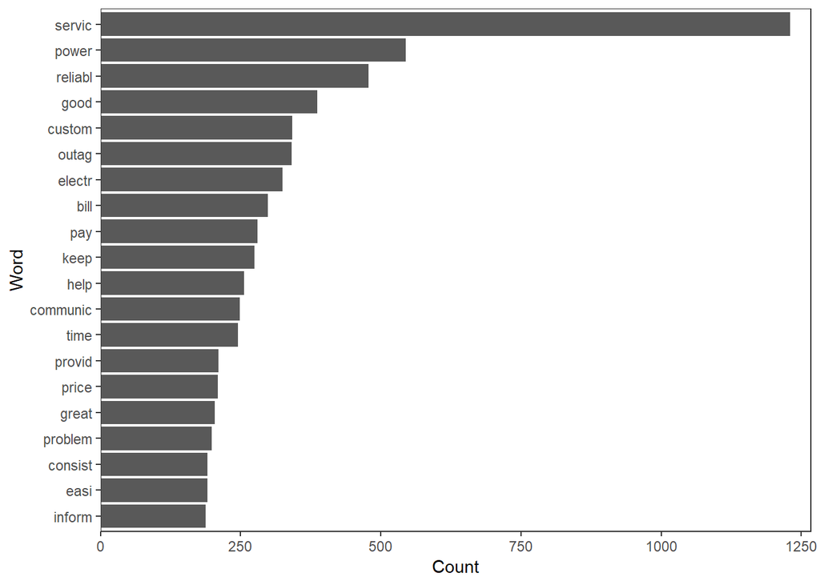

```r
#Find the 20 most frequent terms: term count
term_count1 <- freq_terms(corpus_review1, 20)

# Plot 20 most frequent terms
plot(term_count1)
```

Let’s next identify the most frequently used words in overall Customers Review, for Column 2. ## For Column 2: What.does.DTE.need.to.improve.other.than.price.to.earn.your.sat.

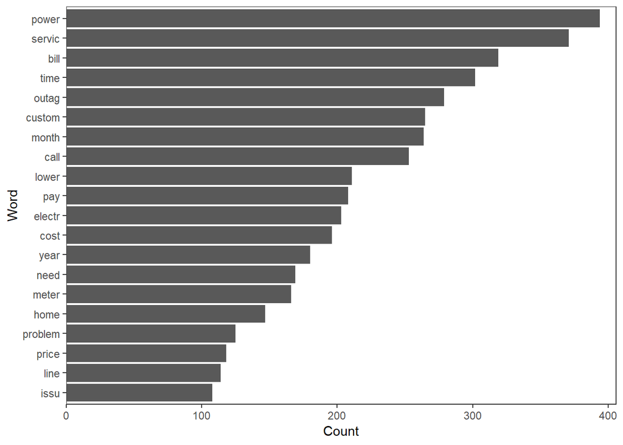

```r
#Find the 20 most frequent terms: term count
term_count2 <- freq_terms(corpus_review2, 20)

# Plot 20 most frequent terms
plot(term_count2)
```

#### Step 4: Create DTM & TDM from corpus

This decides the Document Term Matrix that can help to identify the frequency of terms occuring in the corpuses. In a DTM, Rows correspond to Documents and Columns corresponds to Terms. The TDM is a transpose of DTM.

```r
review_dtm1 <- DocumentTermMatrix(corpus_review1)
review_tdm1 <- TermDocumentMatrix(corpus_review1)

review_dtm2 <- DocumentTermMatrix(corpus_review2)
review_tdm2 <- TermDocumentMatrix(corpus_review2)
```

Let’s use the TDM to identify the frequent terms, by converting them to matrix.

```r
# Convert TDM to matrix
review_m1 <- as.matrix(review_tdm1)
review_m2 <- as.matrix(review_tdm2)
# Sum rows and frequency data frame
review_term_freq1 <- rowSums(review_m1)
review_term_freq2 <- rowSums(review_m2)
# Sort term_frequency in descending order
review_term_freq1 <- sort(review_term_freq1, decreasing = T)
review_term_freq2 <- sort(review_term_freq2, decreasing = T)
# View the top 10 most common words
review_term_freq1[1:10]
```

```
##  servic   power reliabl    good  custom   outag  electr    bill     pay
##    1230     545     478     387     342     341     325     299     280
##    keep
##     275
```

```r
review_term_freq2[1:10]
```

```
##  power servic   bill   time  outag custom  month   call  lower    pay
##    394    371    319    302    279    265    264    253    211    208
```

#### Step 5: Visualization

### Plots

Let’s visualize these tokens of words appearing in the reviews and try to get an idea of what’s mostly appearing in the reviews. ## Column 1: What.does.DTE.do.well.to.earn.your.satisfaction.

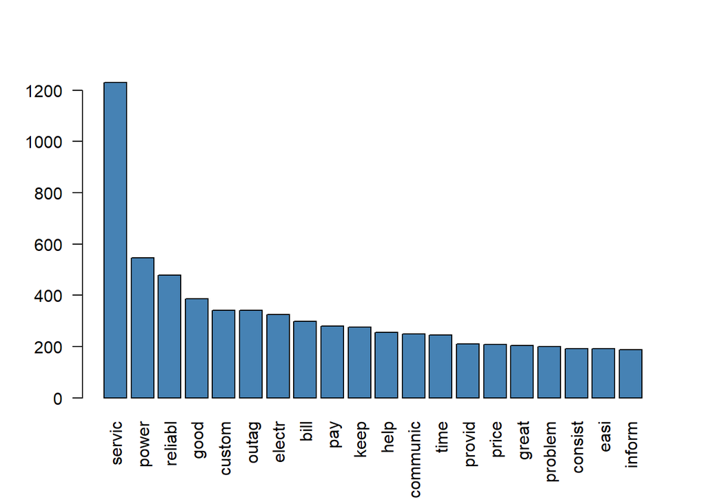

```r
# Plot a barchart of the 20 most common words
barplot(review_term_freq1[1:20], col = "steel blue", las = 2)
```

## Column 2: What.does.DTE.need.to.improve.other.than.price.to.earn.your.sat.

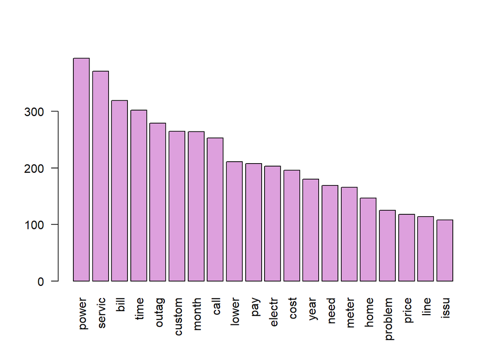

```r
# Plot a barchart of the 20 most common words
barplot(review_term_freq2[1:20], col = "plum", las = 2)
```

### Word Clouds

A much more interesting and common ways of visualizing the frequencies of the words apperaing across each of the documents is by creatung word cloud. This word cloud varies the size of the words based on the frequency of the appearence of each word.

## For Column 1: What.does.DTE.do.well.to.earn.your.satisfaction.

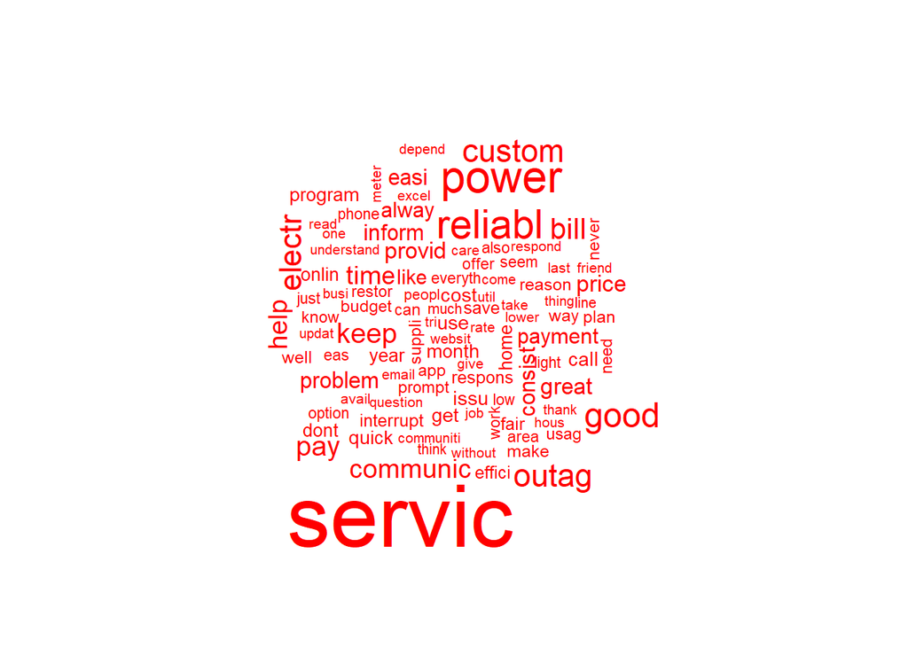

```r
review_word_freq1 <- data.frame(term = names(review_term_freq1),
  num = review_term_freq1)
# Create a wordcloud for the values in word_freqs
wordcloud(review_word_freq1$term, review_word_freq1$num,
  max.words = 100, colors = "red")
```

## For Column 2: What.does.DTE.need.to.improve.other.than.price.to.earn.your.sat.

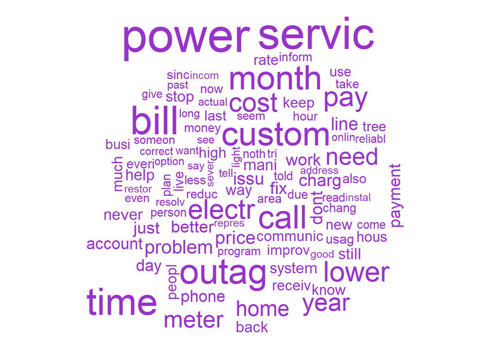

```r
review_word_freq2 <- data.frame(term = names(review_term_freq2),
  num = review_term_freq2)
# Create a wordcloud for the values in word_freqs
wordcloud(review_word_freq2$term, review_word_freq2$num,
  max.words = 100, colors = "darkorchid")
```

Let’s try to distinguish between the more frequent and less frequent words, appearing in both the Columns. ## For Column1: What.does.DTE.do.well.to.earn.your.satisfaction.

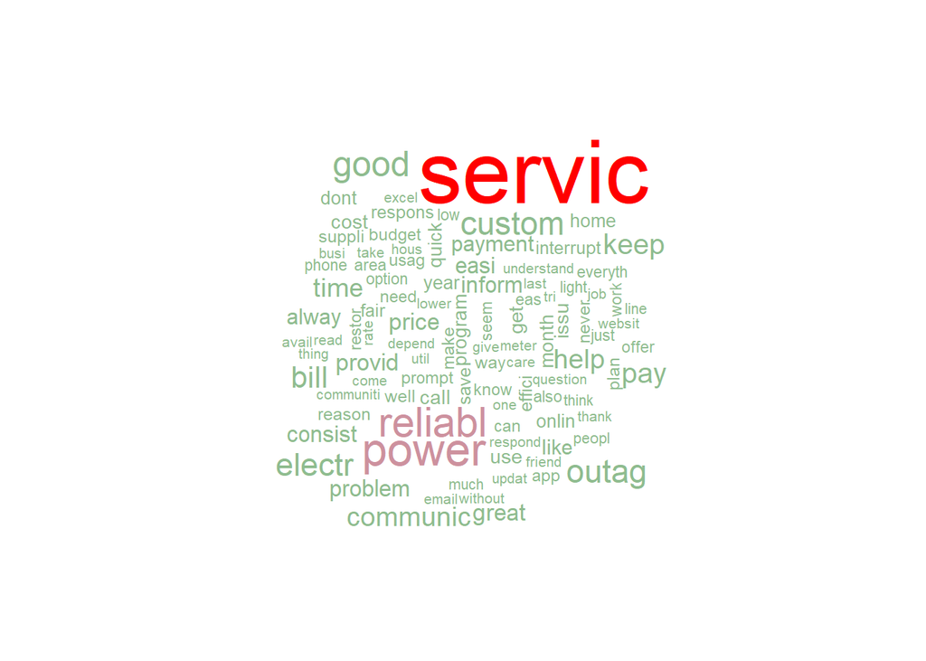

```r
# Print the word cloud with the specified colors
wordcloud(review_word_freq1$term, review_word_freq1$num,
  max.words = 100, colors = c("darkseagreen","pink3","red"))
```

## For Column2: What.does.DTE.need.to.improve.other.than.price.to.earn.your.sat.

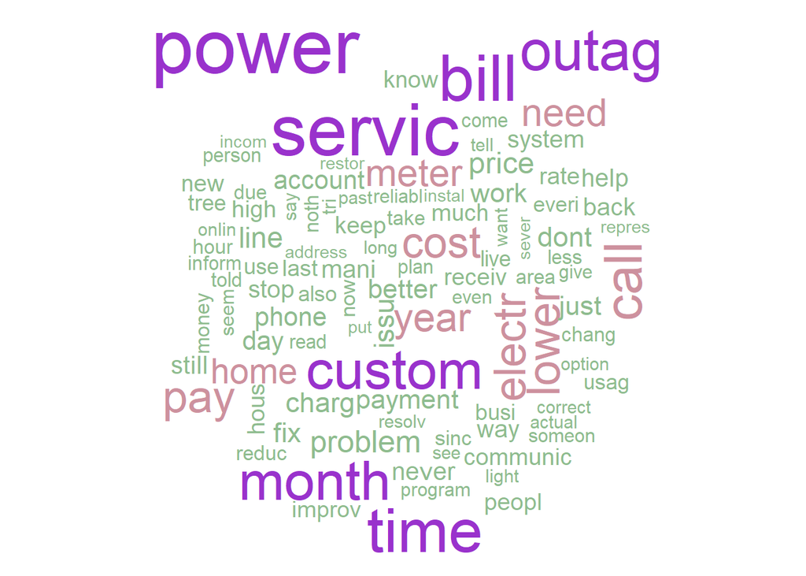

```r
# Print the word cloud with the specified colors
wordcloud(review_word_freq2$term, review_word_freq2$num,
  max.words = 100, colors = c("darkseagreen","pink3","darkorchid"))
```

#### Step 6: Comparing the Corpus

Now, that we have an idea on what all words have appeared mostly across both the survey questions, we can now deep dive to check for words that are appearing in both the two corpuses. For this purpose we need to find the commonality of words between the 2 corpuses (asking two different questions) and plot them in one shared wordcloud.

Next, we will check and compare the dissimilar words shared between the 2 corpuses.

```r
#Taking Up each Question to Paste into a seperate Corpora
all_EarnSatisfaction <- paste(SBLI$EarnSatisfaction, collapse = "")
all_ImproveSatisfaction <- paste(SBLI$ImproveSatisfaction, collapse = "")

#Combining Corpora
all_combine <- c(all_EarnSatisfaction, all_ImproveSatisfaction)

#Creating a new Corpus for the Combined Corpuses
corpus_review_all=Corpus(VectorSource(all_combine))
```

## Preprocessing

Now, that we have both the corpuses, let’s try to remove the punctuations and the stop words from our combined corpuses for the sake of text preprocessing.

```r
#Convert to lower-case
corpus_review_all=tm_map(corpus_review_all, tolower)
#Removing punctuation
corpus_review_all=tm_map(corpus_review_all, removePunctuation)
#Removing Stopwords
corpus_review_all=tm_map(corpus_review_all, removeWords, stopwords("english"))
corpus_review_all=tm_map(corpus_review_all, removeWords,c("dte", "company", "energy", "i", "we", "provide", "gas", "electri*", "dont", "like", "bill", "cost", "need", "work", "go", "get", "use", "one", "can", "make", "price", "also", "due", "will", "keep"))
#Stemming Documents
corpus_review_all=tm_map(corpus_review_all, stemDocument)
review_tdm_all <- TermDocumentMatrix(corpus_review_all)
all_m=as.matrix(review_tdm_all)
colnames(all_m)=c("EarnSatisfaction", "ImproveSatisfaction")

#Sum rows and frequency data frame
review_term_freq_all <- rowSums(all_m)
review_word_freq_all <- data.frame(term=names(review_term_freq_all), num = review_term_freq_all)
```

## Commonality Word Cloud

This word cloud shows the combined frequency of words apperaing in both of the corpuses. In other words this Cloud helps to understand the words that are occuring in both of the Columns that ask the questions: **1. What does DTE do well to earn your satisfaction?** and **2. What does DTE need to improve other than price to earn your satisfaction?**

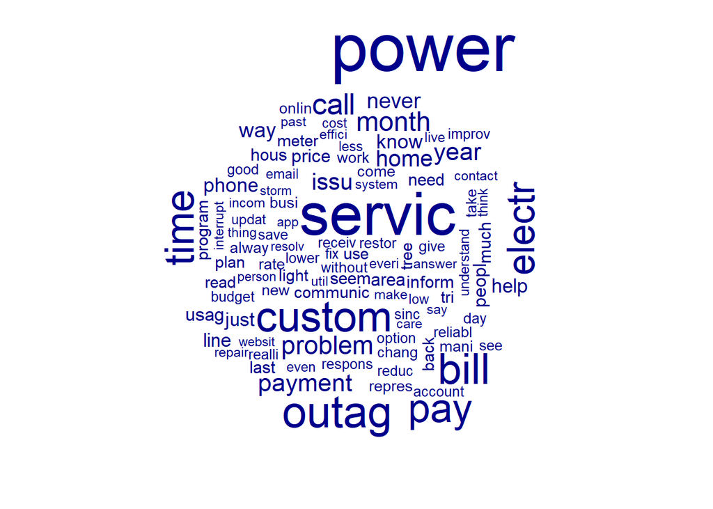

```r
#Make commonality cloud
commonality.cloud(all_m,
                  colors = "darkblue",
                  max.words = 100)
```

## Comparison Word Cloud

The comparison cloud on the other hand will identify dissimilar words used between the 2 corpora, with two different questions asked to the Customers. The demarcation gives an clear indication if the maximum words or sentiments that are appearing in max in these two questions so asked to DTE’s Customers.

**1. EarnSatisfaction: What does DTE do well to earn your satisfaction?** Clearly now we know, how DTE has been earning customer satisfaction by looking at the words that are appearing at a maximum frequency within each corpora as shown in the combined Word Cloud below, indicating the Questions so asked to them.

**2. ImproveSatisfaction: What does DTE need to improve other than price to earn your sat?** In terms of the Question so asked to our Customers that how we can improve our performance other than price, to earn Customer satisfaction we can check out the Word cloud in clear dimarcation indicating the maximum sentiments/words expressed by our Customers while answering to this question.

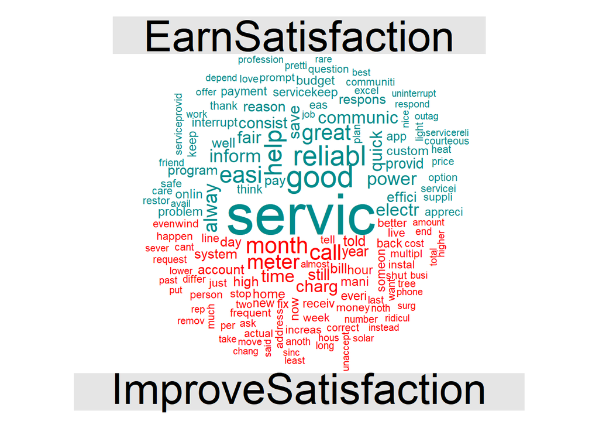

```r
# Create comparison cloud
comparison.cloud(all_m,
                 colors = c("darkcyan", "red"),
                 max.words = 150)
```

## Polarized Tag Plot A polarized tag plot is an improved version of the commonality cloud. It determines the frequency of a term used in both the corpora under comparison. The difference in frequencies of common words might be insightful in many cases. For this plot, the plotrix package is loaded. First a matrix is created with all the common words using a subset to ensure that it contains only words occurring in both the classes. The matrix then has another column for the absolute difference between both the corpora for each word and the plot is made.

```r
#Identify terms shared by both documents
common_words <- subset(all_m, all_m[, 2] > 0 & all_m[, 2] > 0)

#Calculate common words and difference
difference <- abs(common_words[, 1] - common_words[, 2])
common_words <- cbind(common_words, difference)
common_words <- common_words[order(common_words[, 3],
                                   decreasing = T), ]
head(common_words)
```

```
##         EarnSatisfaction ImproveSatisfaction difference
## servic               683                 326        357
## good                 211                  37        174
## reliabl              194                  41        153
## month                110                 242        132
## help                 199                  71        128
## easi                 133                   8        125
```

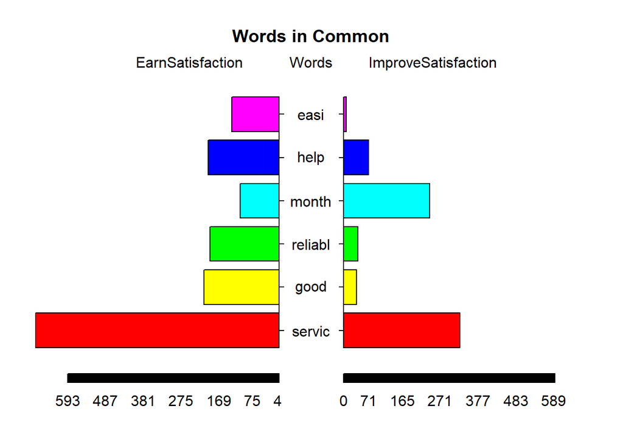

```
## [1] 5.1 4.1 4.1 2.1
```

```r
#Words in Column
top6_df <- data.frame(x = common_words[1:6, 1],
                       y = common_words[1:6, 2],
                       labels = rownames(common_words[1:6, ]))
# Make pyramid plot
pyramid.plot(top6_df$x, top6_df$y,
             labels = top6_df$labels,
             main = "Words in Common",
             gap = 90,
             laxlab = NULL,
             raxlab = NULL,
             unit = NULL, #Can change to % by using "%" instead of NULL
             top.labels = c("EarnSatisfaction",
                            "Words",
                            "ImproveSatisfaction")
             )
```

## Dimension Reduction using Hierarchial Clustering

By Words Clustering, we can visualize which words/group of words are used together based on their frequency distance.

```r
library(cluster)
library(factoextra)
review_tdm_all <- removeSparseTerms(review_tdm_all, sparse = 0.1)
review_tdm_all
```

```
## <<TermDocumentMatrix (terms: 1474, documents: 2)>>
## Non-/sparse entries: 2948/0
## Sparsity           : 0%
## Maximal term length: 17
## Weighting          : term frequency (tf)
```

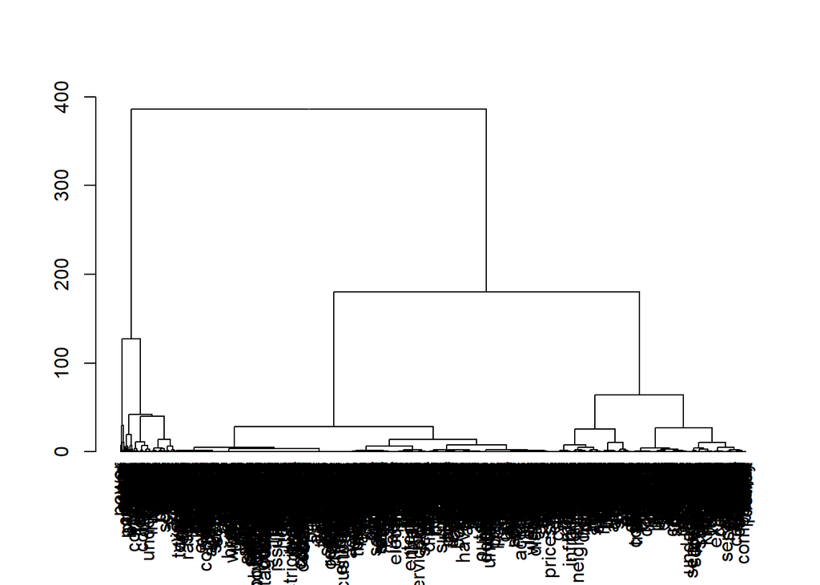

```r
hc <- hclust(d = dist(scale(review_tdm_all), method = "euclidean"), method = "ward.D") #Replace method with "complete", "single", "average", "ward.D", "ward.D2", "mcquitty", "median", "centroid" to see the change in the Dendrogarm appearence along with change in the heights of the tree
# Plot a dendrogram
hcd = as.dendrogram(hc)
plot(hcd)
```

## AGNES

```r
res.agnes <- agnes(review_tdm_all, metric = "euclidean", stand = TRUE, method = "complete")

# Agglomerative coefficient
res.agnes$ac
```

```
## [1] 0.9983419
```

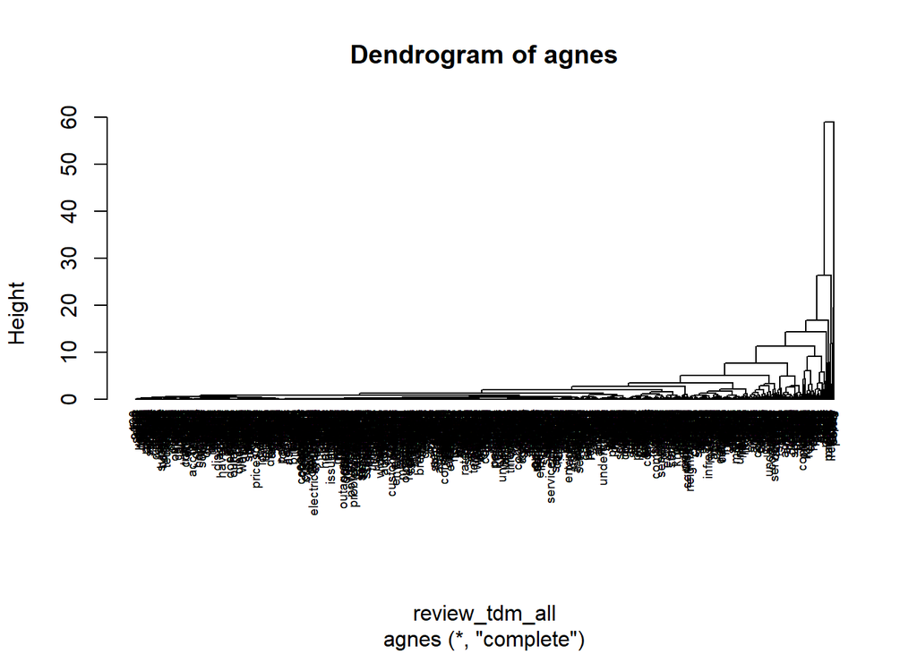

```r
# Plot the tree using pltree()
plot(as.hclust(res.agnes), cex = 0.6, hang = -1,
       main = "Dendrogram of agnes")
```

## DIANA

```r
res.diana <- diana(review_tdm_all, metric = "euclidean", stand = FALSE)

# Agglomerative coefficient
res.diana$ac
```

[output not shown]

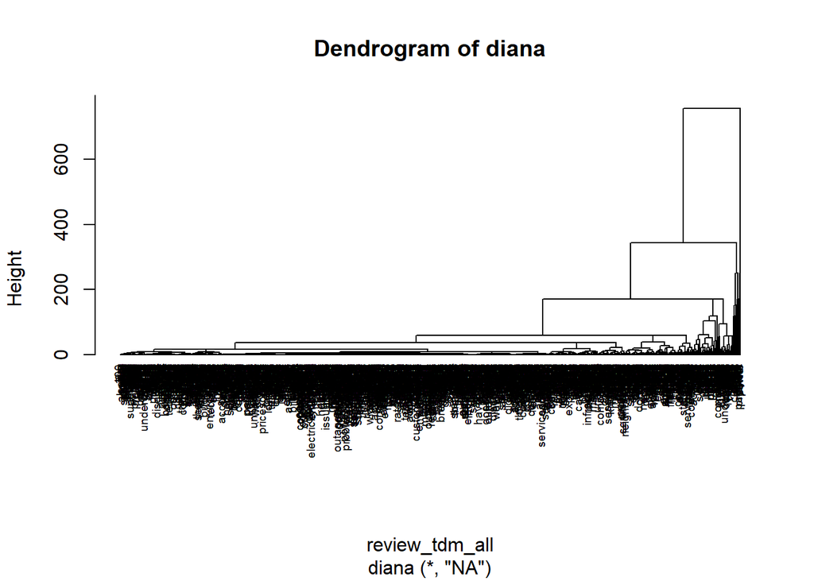

```r
# Plot the tree using pltree()
pltree(res.diana, cex = 0.6, hang = -1,
       main = "Dendrogram of diana")
```

## Zooming in on Dendrograms

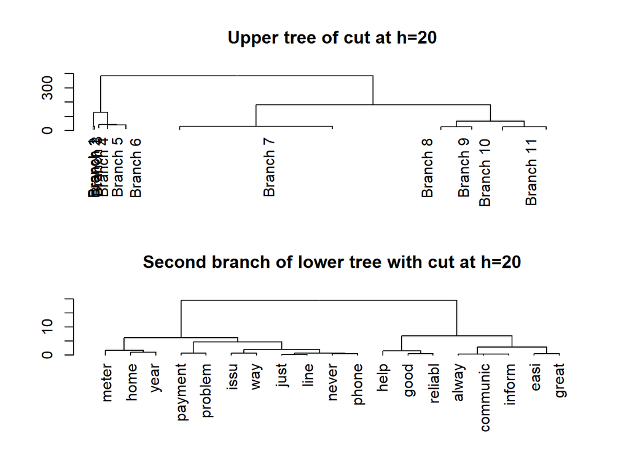

```r
#Plotting Dendrograms with some Cuts
op = par(mfrow = c(2, 1))   #decides the rows at which the visuals will be shown
plot(cut(hcd, h = 20)$upper, main = "Upper tree of cut at h=20")
plot(cut(hcd, h = 20)$lower[[3]], main = "Second branch of lower tree with cut at h=20")
```

### Zooming to the first Dendrogram

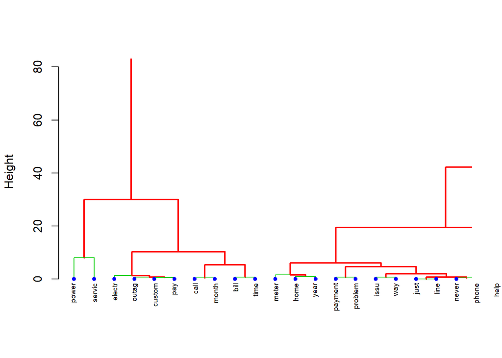

```r
# Zoom in to the first dendrogram
nodePar <- list(lab.cex = 0.6, pch = c(NA, 19),
                cex = 0.7, col = "blue")

plot(hcd, xlim = c(1, 20), ylim = c(1,80), ylab = "Height", nodePar = nodePar,
     edgePar = list(col = 2:3, lwd = 2:1))
```

## Deep Dive

```r
# Sum over all the Columns that indicates the number of Columns, we have 2 questions that we asked so technically we should get 2 as the length
freq <- colSums(as.matrix(review_tdm_all))
length(freq)
```

```
## [1] 2
```

```r
# Frequency in descending order of terms
ord <- order(freq, decreasing = FALSE)
freq[head(ord)]
```

```
##     1     2
## 16390 18359
```

```r
# Finds words that occur 10 times in the entire corpus.
# With increasing value increase the value of lowfreq to 80-100 to check the occurrence of these words 80 times and 100 times respectively within the entire corpus.
findFreqTerms(review_tdm_all, lowfreq = 100)
```

```
##  [1] "account"  "alway"    "area"     "back"     "bill"     "budget"
##  [7] "busi"     "call"     "charg"    "communic" "consist"  "custom"
## [13] "day"      "easi"     "effici"   "electr"   "everi"    "fix"
## [19] "good"     "great"    "help"     "home"     "hous"     "inform"
## [25] "issu"     "just"     "know"     "last"     "light"    "line"
## [31] "live"     "mani"     "meter"    "month"    "much"     "need"
## [37] "never"    "new"      "onlin"    "outag"    "pay"      "payment"
## [43] "peopl"    "phone"    "plan"     "power"    "price"    "problem"
## [49] "program"  "provid"   "rate"     "reason"   "receiv"   "reliabl"
## [55] "respons"  "save"     "seem"     "servic"   "still"    "system"
## [61] "take"     "think"    "time"     "tree"     "usag"     "use"
## [67] "way"      "work"     "year"
```

## Word Associations

Let’s next check the associations of each word so used in the Corpuses. This helps to identify words that appear together. Higher the correlation limit, higher are these words associations with the word so provideed within the quotations or provided as vectors.

From the results below ot looks like that even at a very low coefficient rate as low as **0.1** the association of the word “help” with all these other words is 1.0, indicating all these words appear together and hence the correlation is 1.

We can play with different words to see how these associations with these different keywords change.

```r
findAssocs(review_tdm_all, c("help","power", "outag"), corlimit=0.1) #change corlimit to see how association changes
```

[output not shown]

[output cut: 448 more lines]

```
##             1             1             1             1             1
##         truli          type        unawar    understand   uninterrupt
##             1             1             1             1             1
##         updat          usag         usual          util       various
##             1             1             1             1             1
##           via          view        visibl     voicemail          warm
##             1             1             1             1             1
##         water           way           web        websit      websitei
##             1             1             1             1             1
##       weekend          well          what        whenev       whether
##             1             1             1             1             1
##          will          wise       without          wood          work
##             1             1             1             1             1
##        worker         worri         write
##             1             1             1
```

```r
#tm
```

## Bi-Grams

### Top 10 Bi Grams for the 1st Column asking the question:What.does.DTE.do.well.to.earn.your.satisfaction.

```r
review_bigram1 <- tokens(SBLI$EarnSatisfaction) %>%
    tokens_remove("[^[:alnum:]]", valuetype = "regex", padding = TRUE) %>% #removes punctuation but leaves empty spaces where these were removed
    tokens_remove(stopwords("english"), padding  = TRUE) %>%
    tokens_ngrams(n = 2) %>%
    dfm()
topfeatures(review_bigram1)
```

```
##   customer_service   reliable_service       good_service
##                234                116                 85
##      power_outages        gas_service      good_customer
##                 72                 52                 48
##     great_customer consistent_service         dte_energy
##                 45                 40                 36
##        natural_gas
##                 34
```

## Feature Frequency for Bi-Gram of Question 1:What.does.DTE.do.well.to.earn.your.satisfaction.

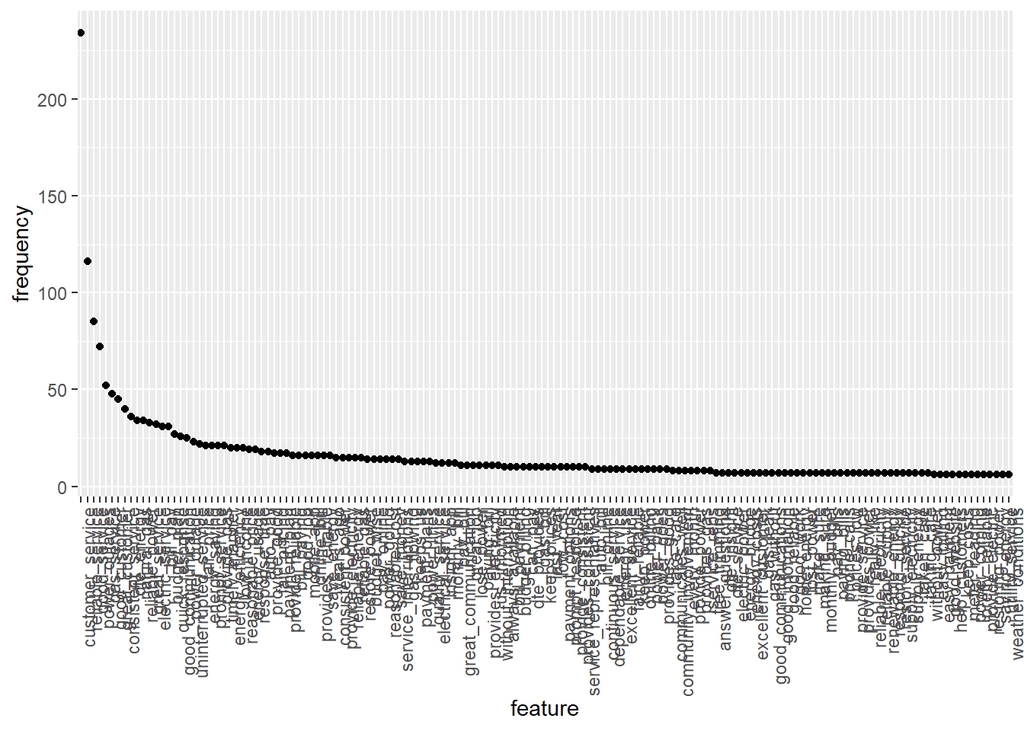

```r
rb1 <- textstat_frequency(review_bigram1, n = 150)

# Sort by reverse frequency order
rb1$feature <- with(rb1, reorder(feature, -frequency))

ggplot(rb1, aes(x = feature, y = frequency), colour = frequency) +
    geom_point() +
    theme(axis.text.x = element_text(angle = 90, hjust = 1))
```

#Graph beautification for later(Need to Work on it)

```r
# library(ggpubr)
# ggbarplot(rb1, x = "feature", y = "frequency",
#           fill = "frequency",           # change fill color by mpg_level
#           color = "white",            # Set bar border colors to white
#           palette = "jco",            # jco journal color palett. see ?ggpar
#           sort.val = "desc",          # Sort the value in descending order
#           sort.by.groups = FALSE,     # Don't sort inside each group
#           x.text.angle = 90,          # Rotate vertically x axis texts
#           ylab = "frequency",
#           legend.title = "MPG Group",
#           rotate = TRUE,
#           ggtheme = theme_minimal()
#           )

#Use color paletes to change color for the Lollypop Chart Visuals
#http://www.sthda.com/english/articles/32-r-graphics-essentials/125-ggplot-cheat-sheet-for-great-customization/
```

### DTE Corporate Citizenship

## Fetching Bi-grams specific to Question 1 related to Corporate Citizenship

```r
rb1 <- rb1[c(14,22,26:27,33,37,40,49,52,56,60,76,74,102,112,126,142),c(1:5)]
```

# Bi-Gram Visualization for Question 1:What.does.DTE.do.well.to.earn.your.satisfaction.

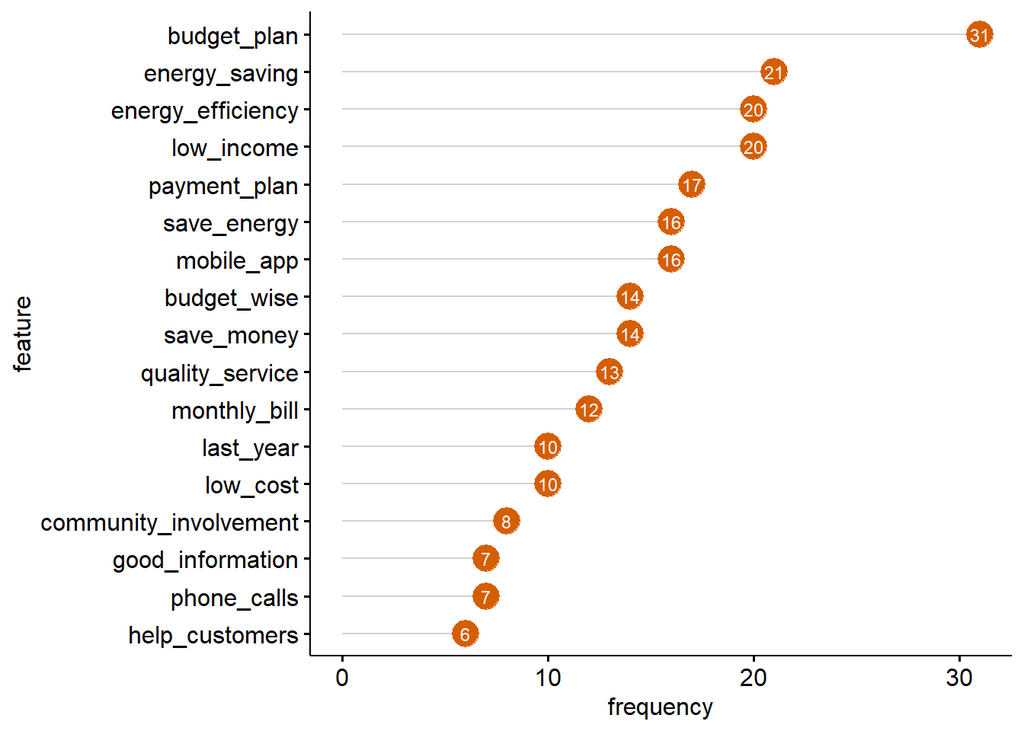

```r
#Lollypop Chart
library(ggpubr)
ggdotchart(rb1, x = "feature", y = "frequency",
           #color = "rank",                                # Color by groups
           color = c("#D55E00"),                         # Custom color palette
           sorting = "descending",                       # Sort value in descending order
           add = "segments",                             # Add segments from y = 0 to dots
           rotate = TRUE,                                # Rotate vertically
           #group = "rank",                                # Order by groups
           dot.size = 6,                                 # Large dot size
           label = (rb1$frequency),                        # Add mpg values as dot labels
           font.label = list(color = "white", size = 9,
                             vjust = 0.5),               # Adjust label parameters
           ggtheme = theme_pubr()                        # ggplot2 theme
           )
```

### Top 10 Bi Grams for the 2nd Column asking the question: What.does.DTE.need.to.improve.other.than.price.to.earn.your.sat.

```r
review_bigram2 <- tokens(SBLI$ImproveSatisfaction) %>%
    tokens_remove("[^[:alnum:]]", valuetype = "regex", padding = TRUE) %>% #removes punctuation but leaves empty spaces where these were removed
    tokens_remove(stopwords("english"), padding  = TRUE) %>%
    tokens_ngrams(n = 2) %>%
    dfm()
topfeatures(review_bigram2)
```

```
## customer_service    power_outages       low_income     power_outage
##              100               86               25               24
##     lower_prices    electric_bill      natural_gas         auto_pay
##               23               23               23               21
##      lower_rates        last_year
##               19               19
```

## Feature Frequency for Bi-Gram of Question 2:What.does.DTE.need.to.improve.other.than.price.to.earn.your.sat.

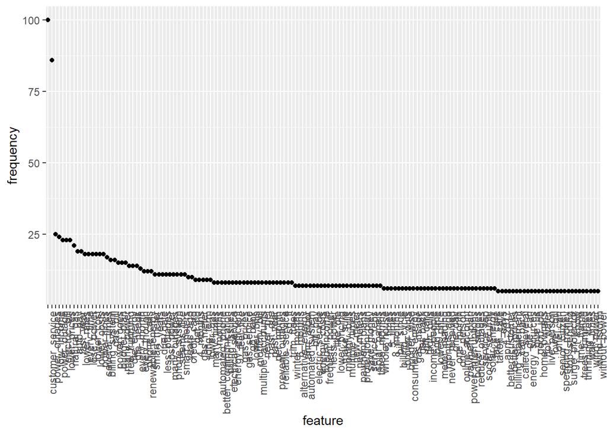

```r
rb2 <- textstat_frequency(review_bigram2, n = 150)

# Sort by reverse frequency order
rb2$feature <- with(rb2, reorder(feature, -frequency))

ggplot(rb2, aes(x = feature, y = frequency)) +
    geom_point() +
    theme(axis.text.x = element_text(angle = 90, hjust = 1))
```

## Fetching Bi-grams specific to Question 2 related to Corporate Citizenship

```r
rb2 <- rb2[c(3,20,27:28,34,59:60,76,78,84,89,105,107,113,129,142),c(1:5)]
```

# Bi-Gram Visualization for Question 2:What.does.DTE.need.to.improve.other.than.price.to.earn.your.sat.

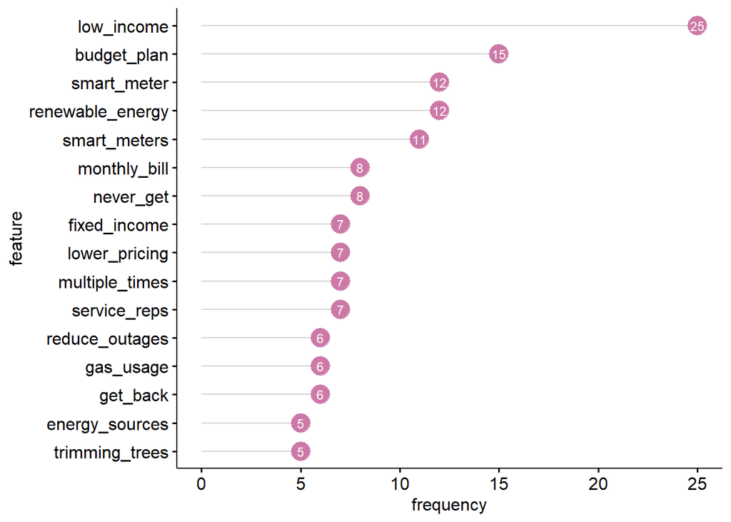

```r
ggdotchart(rb2, x = "feature", y = "frequency",
           #color = "rank",                                # Color by groups
           color = c("#CC79A7"),                         # Custom color palette
           sorting = "descending",                       # Sort value in descending order
           add = "segments",                             # Add segments from y = 0 to dots
           rotate = TRUE,                                # Rotate vertically
           #group = "rank",                                # Order by groups
           dot.size = 6,                                 # Large dot size
           label = (rb2$frequency),                        # Add mpg values as dot labels
           font.label = list(color = "white", size = 9,
                             vjust = 0.5),               # Adjust label parameters
           ggtheme = theme_pubr()                        # ggplot2 theme
           )
```

## Tri-Grams

```r
review_trigram1 <- tokens(SBLI$EarnSatisfaction) %>%
    tokens_remove("[^[:alnum:]]", valuetype = "regex", padding = TRUE) %>% #removes punctuation but leaves empty spaces where these were removed
    tokens_remove(stopwords("english"), padding  = TRUE) %>%
    tokens_ngrams(n = 3) %>%
    dfm()
topfeatures(review_trigram1)
```

```
##           great_customer_service            good_customer_service
##                               44                               44
##             reliable_gas_service             provide_good_service
##                               12                               11
## customer_service_representatives                  online_bill_pay
##                                8                                8
##            customer_service_reps                keeps_us_informed
##                                7                                7
##                    auto_bill_pay        provides_reliable_service
##                                7                                7
```

## Feature Frequency for Tri-Gram of Question 1:What.does.DTE.do.well.to.earn.your.satisfaction.

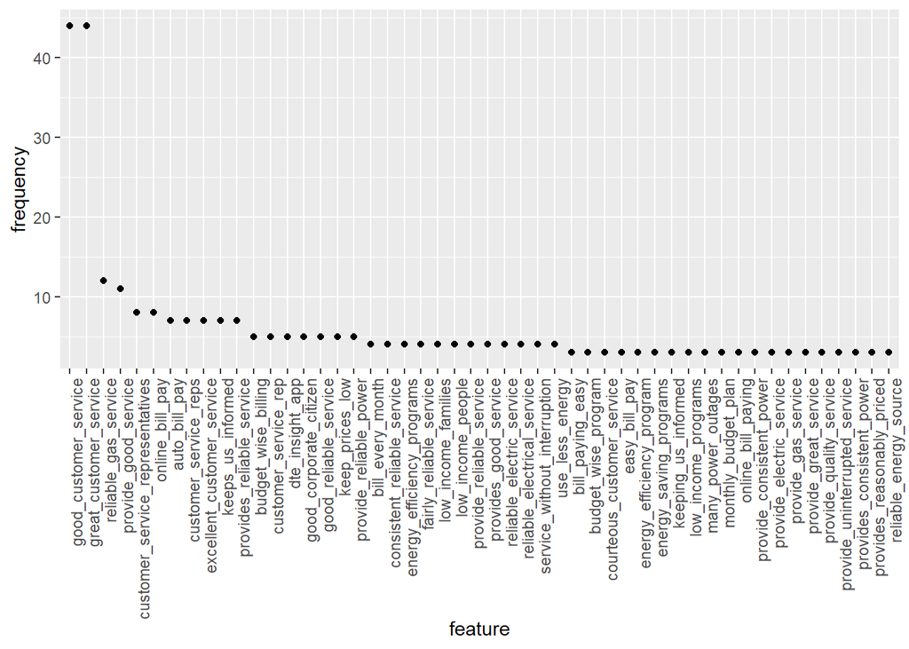

```r
rt1 <- textstat_frequency(review_trigram1, n = 50)

# Sort by reverse frequency order
rt1$feature <- with(rt1, reorder(feature, -frequency))

ggplot(rt1, aes(x = feature, y = frequency)) +
    geom_point() +
    theme(axis.text.x = element_text(angle = 90, hjust = 1))
```

```r
review_trigram2 <- tokens(SBLI$ImproveSatisfaction) %>%
    tokens_remove("[^[:alnum:]]", valuetype = "regex", padding = TRUE) %>% #removes punctuation but leaves empty spaces where these were removed
    tokens_remove(stopwords("english"), padding  = TRUE) %>%
    tokens_ngrams(n = 3) %>%
    dfm()
topfeatures(review_trigram2)
```

```
##     many_power_outages frequent_power_outages  customer_service_reps
##                     13                      7                      6
##            2_years_ago   called_several_times     less_power_outages
##                      5                      5                      5
##      low_income_people automated_phone_system   better_payment_plans
##                      5                      5                      4
##    low_income_families
##                      4
```

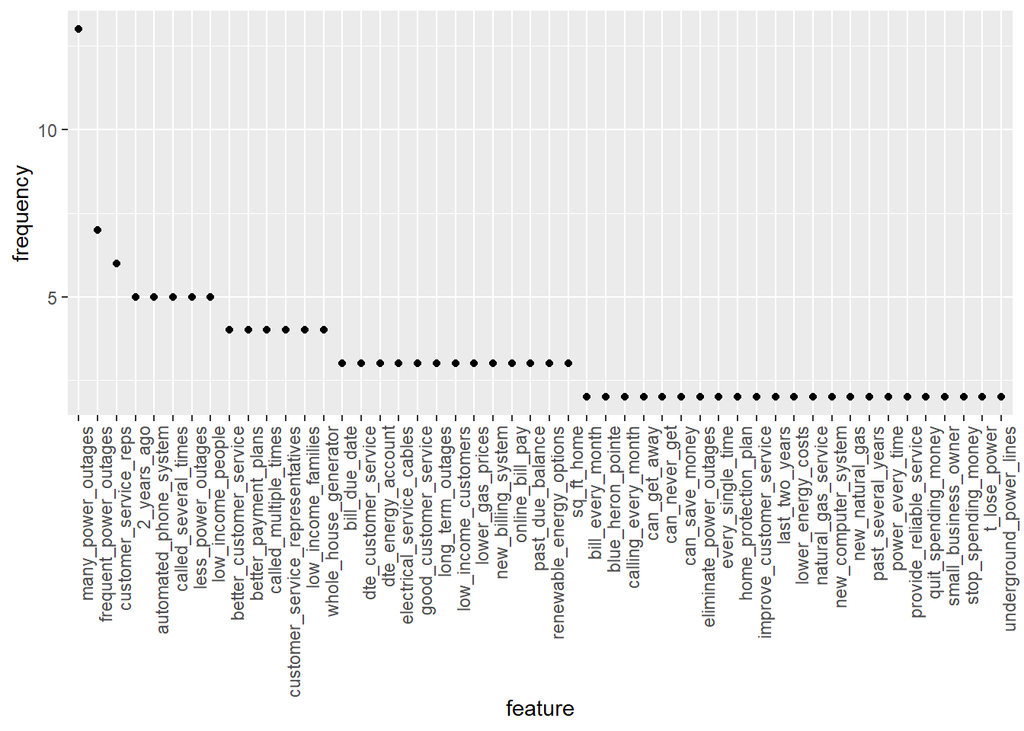

```r
rt2 <- textstat_frequency(review_trigram2, n = 50)

# Sort by reverse frequency order
rt2$feature <- with(rt2, reorder(feature, -frequency))

ggplot(rt2, aes(x = feature, y = frequency)) +
    geom_point() +
    theme(axis.text.x = element_text(angle = 90, hjust = 1))
```

#### Sentiment Analysis

```r
library(SentimentAnalysis)
#Overall Sentiments Across Both the Questions asked
sentimentall <- analyzeSentiment(corpus_review_all)
```

### Overall Sentiment Co-efficient

```r
sentimentall <- na.omit(sentimentall)
sentimentall$SentimentQDAP
```

```
## [1] 0.1425968 0.0529139
```

```r
sentimentall$SentimentLM
```

```
## [1]  0.006858842 -0.046867897
```

```r
sentimentall$SentimentGI
```

```
## [1] 0.11775145 0.04364033
```

```r
sentimentall$SentimentHE
```

```
## [1] 0.01271044 0.00481862
```

### Overall Binary Sentiment Response From Customers

```r
convertToDirection(sentimentall$SentimentQDAP)
```

```
## [1] positive positive
## Levels: negative neutral positive
```

```r
convertToDirection(sentimentall$SentimentLM)
```

```
## [1] positive negative
## Levels: negative neutral positive
```

```r
convertToDirection(sentimentall$SentimentGI)
```

```
## [1] positive positive
## Levels: negative neutral positive
```

```r
convertToDirection(sentimentall$SentimentHE)
```

```
## [1] positive positive
## Levels: negative neutral positive
```

### Overall Sentiments As per Response for Dictionary QDAP:

```r
#Exploring Response as per Dictionary QDAP
responseall <- c(+1, +1)
#compareToResponse(sentimentall, responseall)
compareToResponse(sentimentall, convertToBinaryResponse(responseall))
```

```
##                            WordCount SentimentGI NegativityGI PositivityGI
## Accuracy                         1.0  1.00000000    1.0000000    1.0000000
## Precision                        NaN         NaN          NaN          NaN
## Sensitivity                      NaN         NaN          NaN          NaN
## Specificity                      1.0  1.00000000    1.0000000    1.0000000
## F1                               0.0  0.00000000    0.0000000    0.0000000
## BalancedAccuracy                 NaN         NaN          NaN          NaN
## avg.sentiment.pos.response   21423.5  0.08069589    0.1220878    0.2027837
## avg.sentiment.neg.response       NaN         NaN          NaN          NaN
##                            SentimentHE NegativityHE PositivityHE
## Accuracy                   1.000000000  1.000000000   1.00000000
## Precision                          NaN          NaN          NaN
## Sensitivity                        NaN          NaN          NaN
## Specificity                1.000000000  1.000000000   1.00000000
## F1                         0.000000000  0.000000000   0.00000000
## BalancedAccuracy                   NaN          NaN          NaN
## avg.sentiment.pos.response 0.008764531  0.008456363   0.01722089
## avg.sentiment.neg.response         NaN          NaN          NaN
##                            SentimentLM NegativityLM PositivityLM
## Accuracy                    0.50000000   1.00000000   1.00000000
## Precision                   0.00000000          NaN          NaN
## Sensitivity                        NaN          NaN          NaN
## Specificity                 0.50000000   1.00000000   1.00000000
## F1                          0.00000000   0.00000000   0.00000000
## BalancedAccuracy                   NaN          NaN          NaN
## avg.sentiment.pos.response -0.02000453   0.05978425   0.03977972
## avg.sentiment.neg.response         NaN          NaN          NaN
##                            RatioUncertaintyLM SentimentQDAP NegativityQDAP
## Accuracy                           1.00000000    1.00000000     1.00000000
## Precision                                 NaN           NaN            NaN
## Sensitivity                               NaN           NaN            NaN
## Specificity                        1.00000000    1.00000000     1.00000000
## F1                                 0.00000000    0.00000000     0.00000000
## BalancedAccuracy                          NaN           NaN            NaN
## avg.sentiment.pos.response         0.01240284    0.09775533     0.05995142
## avg.sentiment.neg.response                NaN           NaN            NaN
##                            PositivityQDAP
## Accuracy                        1.0000000
## Precision                             NaN
## Sensitivity                           NaN
## Specificity                     1.0000000
## F1                              0.0000000
## BalancedAccuracy                      NaN
## avg.sentiment.pos.response      0.1577068
## avg.sentiment.neg.response            NaN
```

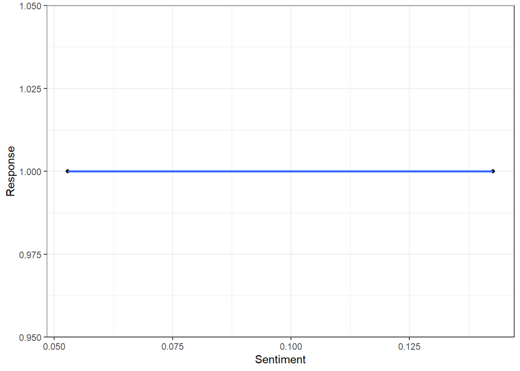

```r
plotSentimentResponse(sentimentall$SentimentQDAP, responseall)
```

### Overall Sentiments As per Response for Dictionary LM:

This indicates that the overall response for both the Questions are Positive and Negative with the Co-efficient of Sentiments flowing across both the questions ranging within 0.006 to -0.0468, respectively.

```r
#Exploring Response as per Dictionary LM
rm(responseall)

responseall <- c(+1, -1)
#compareToResponse(sentimentall, responseall)
compareToResponse(sentimentall, convertToBinaryResponse(responseall))
```

```
##                            WordCount SentimentGI NegativityGI PositivityGI
## Accuracy                         0.5  0.50000000    0.5000000    0.5000000
## Precision                        NaN         NaN          NaN          NaN
## Sensitivity                      0.0  0.00000000    0.0000000    0.0000000
## Specificity                      1.0  1.00000000    1.0000000    1.0000000
## F1                               0.0  0.00000000    0.0000000    0.0000000
## BalancedAccuracy                 0.5  0.50000000    0.5000000    0.5000000
## avg.sentiment.pos.response   20849.0  0.11775145    0.1152094    0.2329608
## avg.sentiment.neg.response   21998.0  0.04364033    0.1289663    0.1726066
##                            SentimentHE NegativityHE PositivityHE
## Accuracy                    0.50000000  0.500000000   0.50000000
## Precision                          NaN          NaN          NaN
## Sensitivity                 0.00000000  0.000000000   0.00000000
## Specificity                 1.00000000  1.000000000   1.00000000
## F1                          0.00000000  0.000000000   0.00000000
## BalancedAccuracy            0.50000000  0.500000000   0.50000000
## avg.sentiment.pos.response  0.01271044  0.007002734   0.01971318
## avg.sentiment.neg.response  0.00481862  0.009909992   0.01472861
##                             SentimentLM NegativityLM PositivityLM
## Accuracy                    1.000000000   0.50000000   0.50000000
## Precision                   1.000000000          NaN          NaN
## Sensitivity                 1.000000000   0.00000000   0.00000000
## Specificity                 1.000000000   1.00000000   1.00000000
## F1                          0.666666667   0.00000000   0.00000000
## BalancedAccuracy            1.000000000   0.50000000   0.50000000
## avg.sentiment.pos.response  0.006858842   0.04897117   0.05583002
## avg.sentiment.neg.response -0.046867897   0.07059733   0.02372943
##                            RatioUncertaintyLM SentimentQDAP NegativityQDAP
## Accuracy                           0.50000000     0.5000000     0.50000000
## Precision                                 NaN           NaN            NaN
## Sensitivity                        0.00000000     0.0000000     0.00000000
## Specificity                        1.00000000     1.0000000     1.00000000
## F1                                 0.00000000     0.0000000     0.00000000
## BalancedAccuracy                   0.50000000     0.5000000     0.50000000
## avg.sentiment.pos.response         0.01103170     0.1425968     0.04666890
## avg.sentiment.neg.response         0.01377398     0.0529139     0.07323393
##                            PositivityQDAP
## Accuracy                        0.5000000
## Precision                             NaN
## Sensitivity                     0.0000000
## Specificity                     1.0000000
## F1                              0.0000000
## BalancedAccuracy                0.5000000
## avg.sentiment.pos.response      0.1892657
## avg.sentiment.neg.response      0.1261478
```

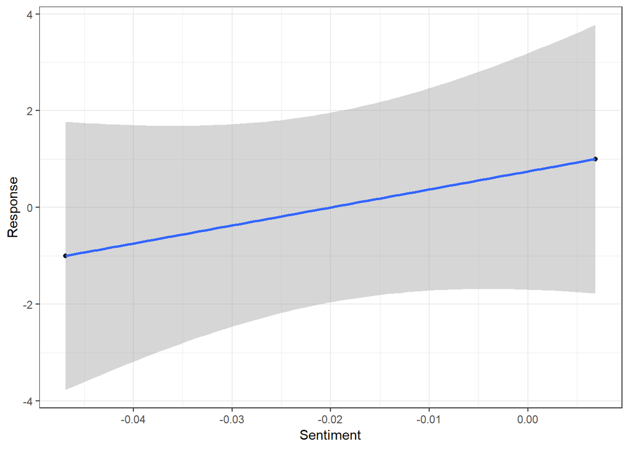

```r
plotSentimentResponse(sentimentall$SentimentLM, responseall)
```

### Overall Sentiments As per Response for Dictionary GI:

This indicates that the overall response for both the Questions are Positive and Positive with the Co-efficient of Sentiments flowing across both the questions ranging within 0.1177 to 0.0436, respectively.

```r
#Exploring Response as per Dictionary GI
rm(responseall)

responseall <- c(+1, +1)
#compareToResponse(sentimentall, responseall)
compareToResponse(sentimentall, convertToBinaryResponse(responseall))
```

```
##                            WordCount SentimentGI NegativityGI PositivityGI
## Accuracy                         1.0  1.00000000    1.0000000    1.0000000
## Precision                        NaN         NaN          NaN          NaN
## Sensitivity                      NaN         NaN          NaN          NaN
## Specificity                      1.0  1.00000000    1.0000000    1.0000000
## F1                               0.0  0.00000000    0.0000000    0.0000000
## BalancedAccuracy                 NaN         NaN          NaN          NaN
## avg.sentiment.pos.response   21423.5  0.08069589    0.1220878    0.2027837
## avg.sentiment.neg.response       NaN         NaN          NaN          NaN
##                            SentimentHE NegativityHE PositivityHE
## Accuracy                   1.000000000  1.000000000   1.00000000
## Precision                          NaN          NaN          NaN
## Sensitivity                        NaN          NaN          NaN
## Specificity                1.000000000  1.000000000   1.00000000
## F1                         0.000000000  0.000000000   0.00000000
## BalancedAccuracy                   NaN          NaN          NaN
## avg.sentiment.pos.response 0.008764531  0.008456363   0.01722089
## avg.sentiment.neg.response         NaN          NaN          NaN
##                            SentimentLM NegativityLM PositivityLM
## Accuracy                    0.50000000   1.00000000   1.00000000
## Precision                   0.00000000          NaN          NaN
## Sensitivity                        NaN          NaN          NaN
## Specificity                 0.50000000   1.00000000   1.00000000
## F1                          0.00000000   0.00000000   0.00000000
## BalancedAccuracy                   NaN          NaN          NaN
## avg.sentiment.pos.response -0.02000453   0.05978425   0.03977972
## avg.sentiment.neg.response         NaN          NaN          NaN
##                            RatioUncertaintyLM SentimentQDAP NegativityQDAP
## Accuracy                           1.00000000    1.00000000     1.00000000
## Precision                                 NaN           NaN            NaN
## Sensitivity                               NaN           NaN            NaN
## Specificity                        1.00000000    1.00000000     1.00000000
## F1                                 0.00000000    0.00000000     0.00000000
## BalancedAccuracy                          NaN           NaN            NaN
## avg.sentiment.pos.response         0.01240284    0.09775533     0.05995142
## avg.sentiment.neg.response                NaN           NaN            NaN
##                            PositivityQDAP
## Accuracy                        1.0000000
## Precision                             NaN
## Sensitivity                           NaN
## Specificity                     1.0000000
## F1                              0.0000000
## BalancedAccuracy                      NaN
## avg.sentiment.pos.response      0.1577068
## avg.sentiment.neg.response            NaN
```

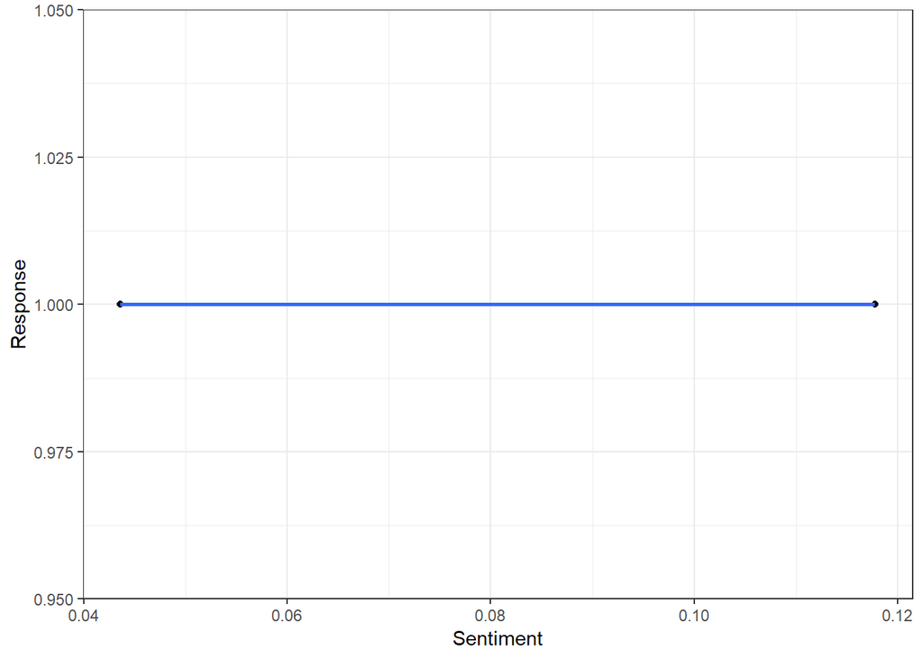

```r
plotSentimentResponse(sentimentall$SentimentGI, responseall)
```

### Overall Sentiments As per Response for Dictionary HE:

This indicates that the overall response for both the Questions are Positive and Positive with the Co-efficient of Sentiments flowing across both the questions ranging within 0.0127 to 0.0048, respectively.

```r
#Exploring Response as per Dictionary HE
rm(responseall)

responseall <- c(+1, +1)
#compareToResponse(sentimentall, responseall)
compareToResponse(sentimentall, convertToBinaryResponse(responseall))
```

```
##                            WordCount SentimentGI NegativityGI PositivityGI
## Accuracy                         1.0  1.00000000    1.0000000    1.0000000
## Precision                        NaN         NaN          NaN          NaN
## Sensitivity                      NaN         NaN          NaN          NaN
## Specificity                      1.0  1.00000000    1.0000000    1.0000000
## F1                               0.0  0.00000000    0.0000000    0.0000000
## BalancedAccuracy                 NaN         NaN          NaN          NaN
## avg.sentiment.pos.response   21423.5  0.08069589    0.1220878    0.2027837
## avg.sentiment.neg.response       NaN         NaN          NaN          NaN
##                            SentimentHE NegativityHE PositivityHE
## Accuracy                   1.000000000  1.000000000   1.00000000
## Precision                          NaN          NaN          NaN
## Sensitivity                        NaN          NaN          NaN
## Specificity                1.000000000  1.000000000   1.00000000
## F1                         0.000000000  0.000000000   0.00000000
## BalancedAccuracy                   NaN          NaN          NaN
## avg.sentiment.pos.response 0.008764531  0.008456363   0.01722089
## avg.sentiment.neg.response         NaN          NaN          NaN
##                            SentimentLM NegativityLM PositivityLM
## Accuracy                    0.50000000   1.00000000   1.00000000
## Precision                   0.00000000          NaN          NaN
## Sensitivity                        NaN          NaN          NaN
## Specificity                 0.50000000   1.00000000   1.00000000
## F1                          0.00000000   0.00000000   0.00000000
## BalancedAccuracy                   NaN          NaN          NaN
## avg.sentiment.pos.response -0.02000453   0.05978425   0.03977972
## avg.sentiment.neg.response         NaN          NaN          NaN
##                            RatioUncertaintyLM SentimentQDAP NegativityQDAP
## Accuracy                           1.00000000    1.00000000     1.00000000
## Precision                                 NaN           NaN            NaN
## Sensitivity                               NaN           NaN            NaN
## Specificity                        1.00000000    1.00000000     1.00000000
## F1                                 0.00000000    0.00000000     0.00000000
## BalancedAccuracy                          NaN           NaN            NaN
## avg.sentiment.pos.response         0.01240284    0.09775533     0.05995142
## avg.sentiment.neg.response                NaN           NaN            NaN
##                            PositivityQDAP
## Accuracy                        1.0000000
## Precision                             NaN
## Sensitivity                           NaN
## Specificity                     1.0000000
## F1                              0.0000000
## BalancedAccuracy                      NaN
## avg.sentiment.pos.response      0.1577068
## avg.sentiment.neg.response            NaN
```

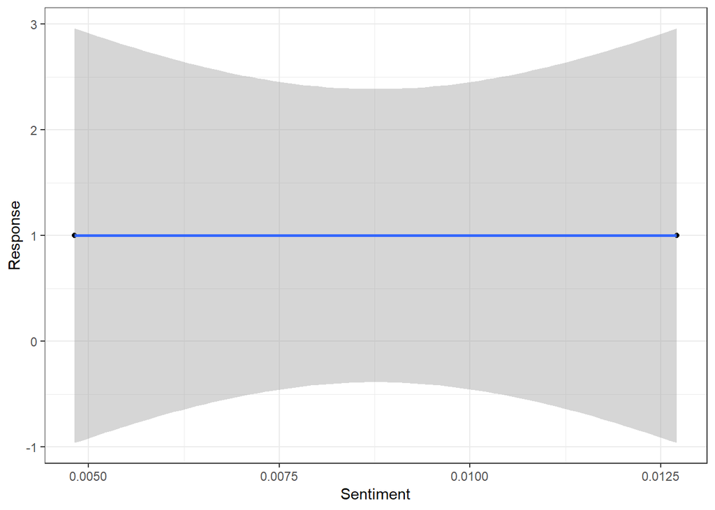

```r
plotSentimentResponse(sentimentall$SentimentHE, responseall)
```

## Sentiments Across Both the Questions Asked seperately

```r
sentiment1 <- analyzeSentiment(corpus_review1)
sentiment2 <- analyzeSentiment(corpus_review2)
```

## Overall Binary Sentiment Response From Customers For the 1st Question: What.does.DTE.do.well.to.earn.your.satisfaction.

```r
sentiment1 <- na.omit(sentiment1)
sentiment1$SentimentQDAP
```

[output not shown]

[output cut: 841 more lines]

```r
response1 <- convertToDirection(sentiment1$SentimentQDAP)
```

## Flow of Reviews Across the 1st Question:What.does.DTE.do.well.to.earn.your.satisfaction.

```r
library("dplyr")
#response1 %>% group_by(positive, negative, neutral) %>% summarize(count=n())
unique(response1)
```

```
## [1] positive neutral  negative
## Levels: negative neutral positive
```

```r
dim(table(response1))
```

```
## [1] 3
```

```r
library(data.table)
```

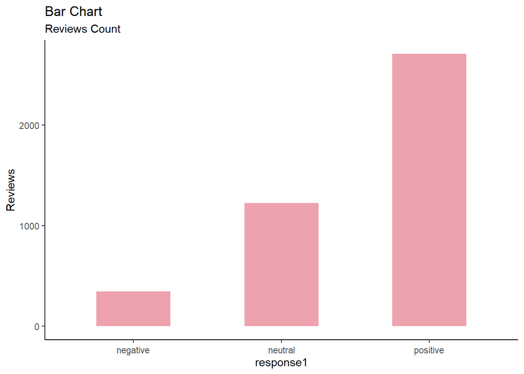

```r
DT1 <- data.table(response1)


#Number of Factors for the Reviews
DT1 <- DT1 %>%
  group_by(response1) %>%
  summarise(Reviews = length(response1))


#Visualization
library("RColorBrewer")
library(ggplot2)
theme_set(theme_classic())


g <- ggplot(DT1, aes(response1, Reviews))
g + geom_bar(stat="identity", width = 0.5, fill="lightpink2") +
      labs(title="Bar Chart",
           subtitle="Reviews Count") +
      theme(axis.text.x = element_text(angle=360, vjust=0.6))
```

```r
# response1 <- c(+1, 0, -1)
# #compareToResponse(sentimentall, responseall)
# compareToResponse(sentiment1, convertToBinaryResponse(response1))
#
# plotSentimentResponse(sentiment1$SentimentQDAP, response1)
```

## Correlation Matrix For Sentiments across 1st Question: What.does.DTE.do.well.to.earn.your.satisfaction.

```r
library(ggcorrplot)
cormat1 <- round(cor(sentiment1),2)
head(cormat1)
```

```
##              WordCount SentimentGI NegativityGI PositivityGI SentimentHE
## WordCount         1.00       -0.05        -0.06        -0.11       -0.04
## SentimentGI      -0.05        1.00        -0.65         0.82        0.20
## NegativityGI     -0.06       -0.65         1.00        -0.10       -0.07
## PositivityGI     -0.11        0.82        -0.10         1.00        0.21
## SentimentHE      -0.04        0.20        -0.07         0.21        1.00
## NegativityHE     -0.01       -0.21         0.20        -0.13       -0.47
##              NegativityHE PositivityHE SentimentLM NegativityLM
## WordCount           -0.01        -0.05       -0.06         0.01
## SentimentGI         -0.21         0.12        0.40        -0.36
## NegativityGI         0.20         0.02       -0.14         0.33
## PositivityGI        -0.13         0.17        0.43        -0.23
## SentimentHE         -0.47         0.90        0.40        -0.11
## NegativityHE         1.00        -0.04       -0.08         0.06
##              PositivityLM RatioUncertaintyLM SentimentQDAP NegativityQDAP
## WordCount           -0.08               0.00         -0.13           0.03
## SentimentGI          0.26              -0.06          0.60          -0.44
## NegativityGI         0.08               0.23         -0.25           0.46
## PositivityGI         0.39               0.10          0.60          -0.24
## SentimentHE          0.46              -0.03          0.21          -0.10
## NegativityHE        -0.06               0.01         -0.12           0.06
##              PositivityQDAP
## WordCount             -0.14
## SentimentGI            0.51
## NegativityGI          -0.09
## PositivityGI           0.60
## SentimentHE            0.20
## NegativityHE          -0.12
```

## Sentiment Distribution Visualization For 1st Question

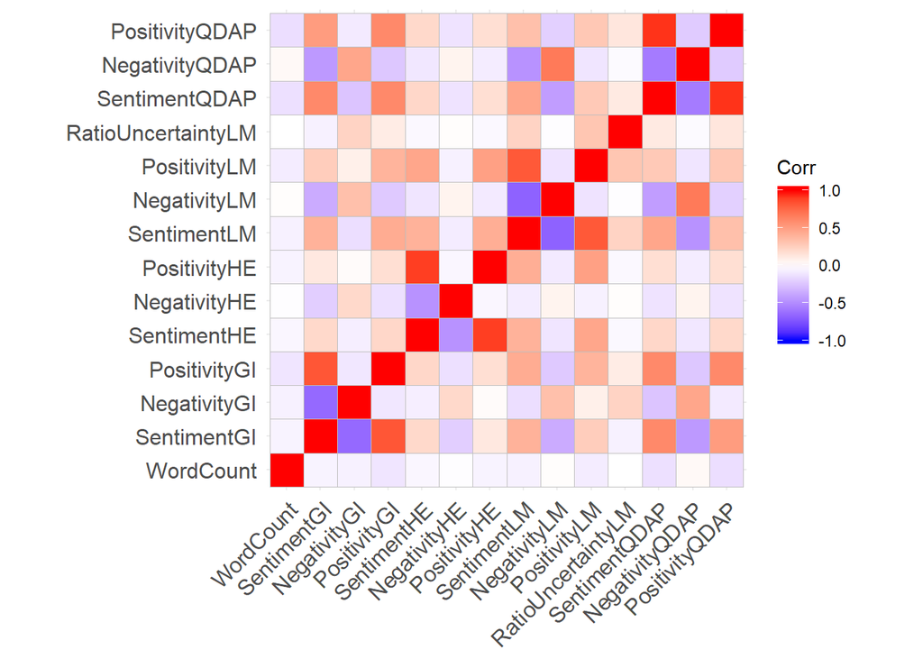

```r
ggcorrplot(cormat1)
```

## Overall Binary Sentiment Response From Customers For the 2nd Question:What.does.DTE.need.to.improve.other.than.price.to.earn.your.sat.

```r
sentiment2 <- na.omit(sentiment2)
sentiment2$SentimentQDAP
```

[output not shown]

[output cut: 315 more lines]

```r
response2 <- convertToDirection(sentiment2$SentimentQDAP)
```

```r
dim(table(response2))
```

```
## [1] 3
```

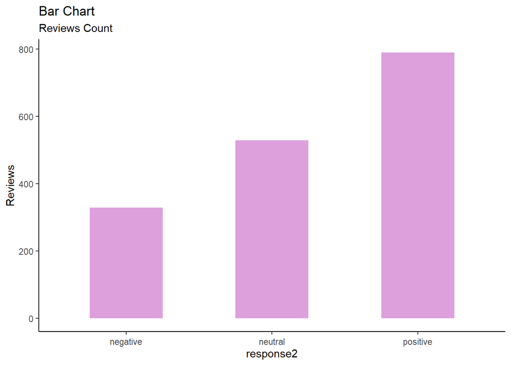

```r
library(data.table)
DT2 <- data.table(response2)


#Number of Factors for the Reviews
DT2 <- DT2 %>%
  group_by(response2) %>%
  summarise(Reviews = length(response2))


#Visualization
library("RColorBrewer")
library(ggplot2)
theme_set(theme_classic())


g <- ggplot(DT2, aes(response2, Reviews))
g + geom_bar(stat="identity", width = 0.5, fill="plum") +
      labs(title="Bar Chart",
           subtitle="Reviews Count") +
      theme(axis.text.x = element_text(angle=360, vjust=0.6))
```

## Correlation Matrix For Sentiments across 2nd Question: What.does.DTE.need.to.improve.other.than.price.to.earn.your.sat.

```r
cormat2 <- round(cor(sentiment2),2)
head(cormat2)
```

```
##              WordCount SentimentGI NegativityGI PositivityGI SentimentHE
## WordCount         1.00        0.07        -0.12        -0.01        0.11
## SentimentGI       0.07        1.00        -0.79         0.77        0.57
## NegativityGI     -0.12       -0.79         1.00        -0.22       -0.57
## PositivityGI     -0.01        0.77        -0.22         1.00        0.31
## SentimentHE       0.11        0.57        -0.57         0.31        1.00
## NegativityHE     -0.18       -0.53         0.60        -0.22       -0.87
##              NegativityHE PositivityHE SentimentLM NegativityLM
## WordCount           -0.18        -0.08        0.02        -0.07
## SentimentGI         -0.53         0.25        0.43        -0.31
## NegativityGI         0.60        -0.13       -0.33         0.32
## PositivityGI        -0.22         0.27        0.35        -0.16
## SentimentHE         -0.87         0.55        0.23        -0.06
## NegativityHE         1.00        -0.07       -0.05         0.01
##              PositivityLM RatioUncertaintyLM SentimentQDAP NegativityQDAP
## WordCount           -0.08               0.08         -0.04           0.00
## SentimentGI          0.37               0.03          0.62          -0.45
## NegativityGI        -0.14              -0.05         -0.45           0.51
## PositivityGI         0.45              -0.01          0.53          -0.19
## SentimentHE          0.37               0.03          0.25          -0.06
## NegativityHE        -0.08              -0.06         -0.16           0.02
##              PositivityQDAP
## WordCount             -0.06
## SentimentGI            0.51
## NegativityGI          -0.21
## PositivityGI           0.59
## SentimentHE            0.30
## NegativityHE          -0.20
```

## Sentiment Distribution Visualization For 2nd Question

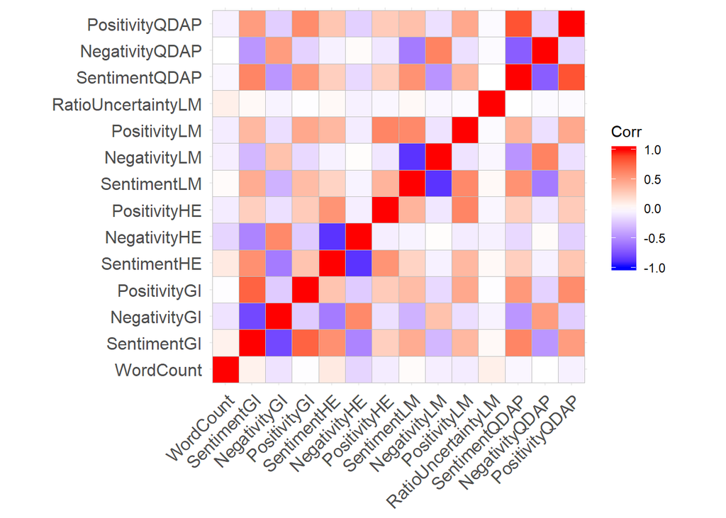

```r
ggcorrplot(cormat2)
```

```r
# SBLI$Survey_Type <- as.factor(SBLI$Survey_Type)
#
# # plot of sentiment by Business Units
# ggplot(SBLI, aes(x = Survey_Type, y = responseall, color = Survey_Type)) +
#   geom_boxplot() #
```

#Freeing Space

```r
rm(sentiment1, sentiment2, hcd, all_m, review_bigram1, review_bigram2, review_trigram, review_dtm1, review_dtm2, review_m1, review_m2, all_combine, review_term_freq_all, review_term_freq1, review_term_freq2, res.agnes, res.diana, common_words, review_tdm1, rt1, rt2, review_tdm2, review_tdm_all, cormat1, cormat2, DictionaryGI, DictionaryHE, DictionaryLM, review_word_freq_all, review_word_freq1, review_word_freq2, DT1, DT2, term_count1, term_count2, top6_df, response1, response2, responseall)
```